# hw2

Karen Gong | PHYS 434 AA - HW 2

```python
%matplotlib inline
import numpy as np
import matplotlib
import matplotlib.pyplot as plt
import scipy
from scipy import stats

plt.rcParams["figure.figsize"] = (15,10)
```

1. Which is more probable when rolling 2 six-sided dice: rolling snake eyes (two ones) or rolling sevens (dice sum to seven)? What is the ratio of the probabilities?

P(2 ones) = 1/36

P(sevens) = 1/6

Rolling sevens is more probable than rolling two ones when rolling two six-sided dice.

The ratio of the probabilites (from P(2 ones) to P(sevens)) is 1/6, so rolling a sum of seven is 6 times more probable than rolling snake eyes.

1. Determine the probability of the sum of 2 six sided dice both analytically (math & counting) and numerically (computer program).

```
[0.027777777777777776, 0.05555555555555555, 0.08333333333333333, 0.1111111111111111, 0.1388888888888889, 0.16666666666666666, 0.1388888888888889, 0.1111111111111111, 0.08333333333333333, 0.05555555555555555, 0.027777777777777776]
```

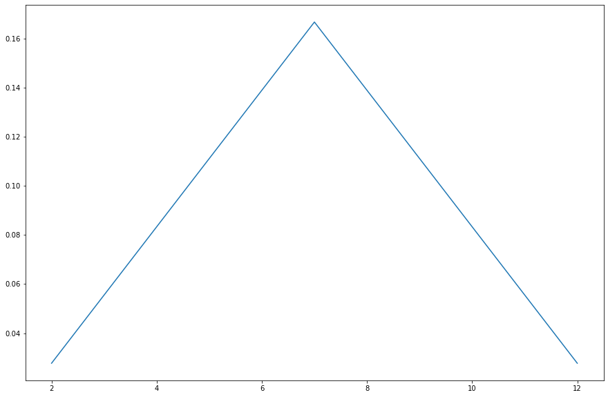

```python
# analytical
p = 1/36
probs = []

p2 = probs.append(p)
p3 = probs.append(p + p)
p4 = probs.append(p + p + p)
p5 = probs.append(4 * p)
p6 = probs.append(5 * p)
p7 = probs.append(6 * p)
p8 = probs.append(5 * p)
p9 = probs.append(4 * p)
p10 = probs.append(3 * p)
p11 = probs.append(2 * p)
p12 = probs.append(p)

print(probs)

# convolution of the two dice graphed
x = range(2, 13)
plt.plot(x, probs)
```

```
[0.02777778 0.05555556 0.08333333 0.11111111 0.13888889 0.16666667
 0.13888889 0.11111111 0.08333333 0.05555556 0.02777778]
```

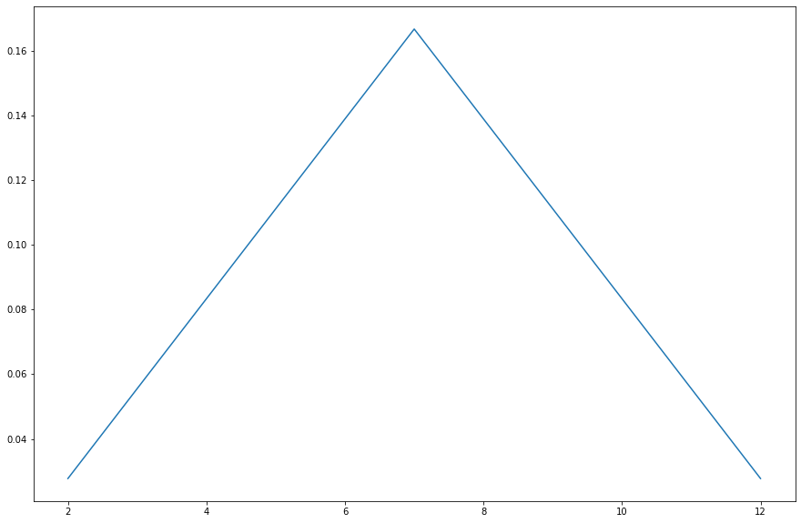

```python
# numerical
# probability of rolling a single number on one dice

p = 6 * [1/6]

numprobs = np.convolve(p, p)
print(numprobs)

# graph of convolution
x = range(2, 13)
plt.plot(x, numprobs)
```

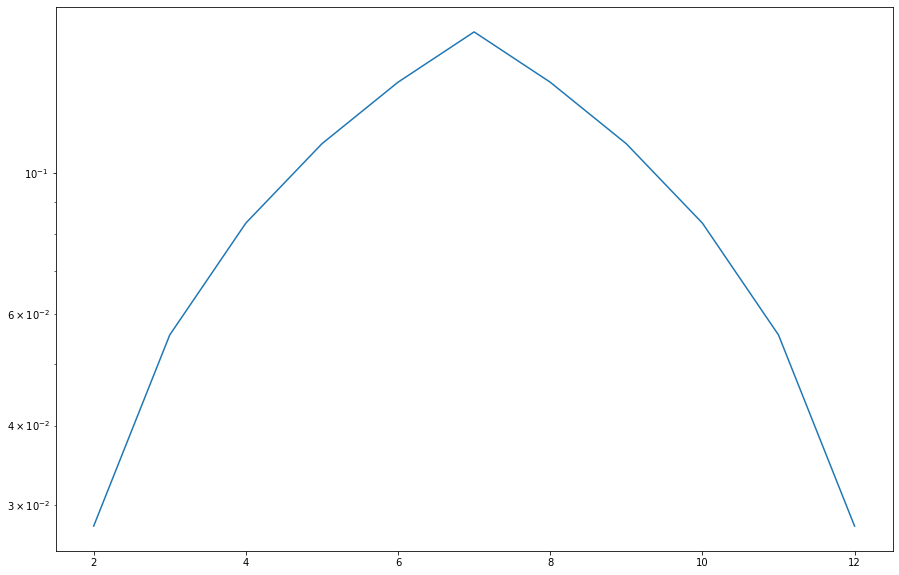

```python
x = range(2, 13)
plt.plot(x, numprobs)
plt.yscale("log")
```

1. Calculate the mean and the variance of the distribution in problem 2.

```python
mean = np.mean(numprobs)
var = np.var(numprobs)

print("mean =", mean)
print("variance =", var)
```

```
mean = 0.09090909090909091
variance = 0.0019768390980512197
```

1. Repeat 2, and graph the average of 10 dice. Is this is a Gaussian distribution? Explain in depth.

The graph looks like a Gaussian distribution. The distribution was summed/averaged over enough trials that it converged to look like a Gaussian pdf. If I were to convolve the distribution more times, it would look increasingly more like a Gaussian distribution.

```
[1.65381717e-08 1.65381717e-07 9.09599443e-07 3.63839777e-06
 1.18247928e-05 3.31094197e-05 8.26081676e-05 1.87542867e-04
 3.92946959e-04 7.67701930e-04 1.40951530e-03 2.44665712e-03
 4.03407353e-03 6.34189270e-03 9.53533096e-03 1.37465945e-02
 1.90415547e-02 2.53867551e-02 3.26236936e-02 4.04573294e-02
 4.84643679e-02 5.61241048e-02 6.28704385e-02 6.81581055e-02
 7.15327194e-02 7.26928060e-02 7.15327194e-02 6.81581055e-02
 6.28704385e-02 5.61241048e-02 4.84643679e-02 4.04573294e-02
 3.26236936e-02 2.53867551e-02 1.90415547e-02 1.37465945e-02
 9.53533096e-03 6.34189270e-03 4.03407353e-03 2.44665712e-03
 1.40951530e-03 7.67701930e-04 3.92946959e-04 1.87542867e-04
 8.26081676e-05 3.31094197e-05 1.18247928e-05 3.63839777e-06
 9.09599443e-07 1.65381717e-07 1.65381717e-08]
```

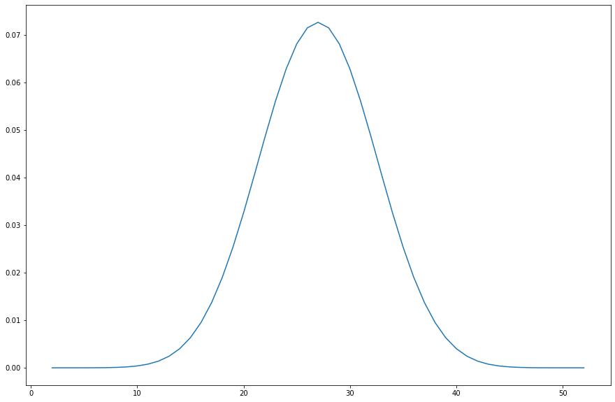

```python
p = 6 * [1/6]

d2 = np.convolve(p, p)
d3 = np.convolve(d2, p)
d4 = np.convolve(d3, p)
d5 = np.convolve(d4, p)
d6 = np.convolve(d5, p)
d7 = np.convolve(d6, p)
d8 = np.convolve(d7, p)
d9 = np.convolve(d8, p)
d10 = np.convolve(d9, p)

print(d10)
# graph of convolution
x = range(2, 53)
plt.plot(x, d10)

mean = np.mean(d10)
var = np.var(d10)
```

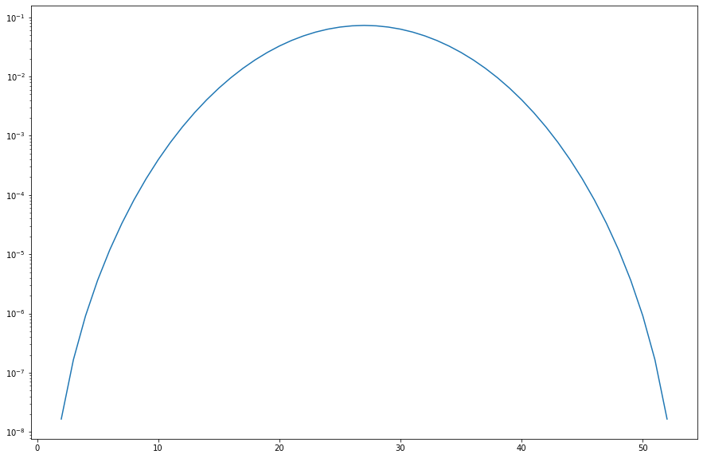

```python
#distribution on log scale
x = range(2, 53)
plt.plot(x, d10)
plt.yscale("log")
```

1. Show that the sum and average of an initially Gaussian distribution is also a Gaussian (can be analytic or numerical). How does the standard deviation of the resulting sum or average Guassian change? This is a hugely important result. Explore what this means for integrating a signal over time.

As the distribution is convolved more often, the standard deviation of the resulting sum/average Gaussian increases. The high standard deviation means that values are very spread out compared to the mean. That means for integrating a signal over time, the signal gets larger and wider. The more times a signal is integrated over, the greater the signal becomes.

```
Standard deviation of intial Gaussian distribution: 0.34950895694706985
Standard deviation of summed/averaged over Gaussian distribution: 846847.0509047465
```

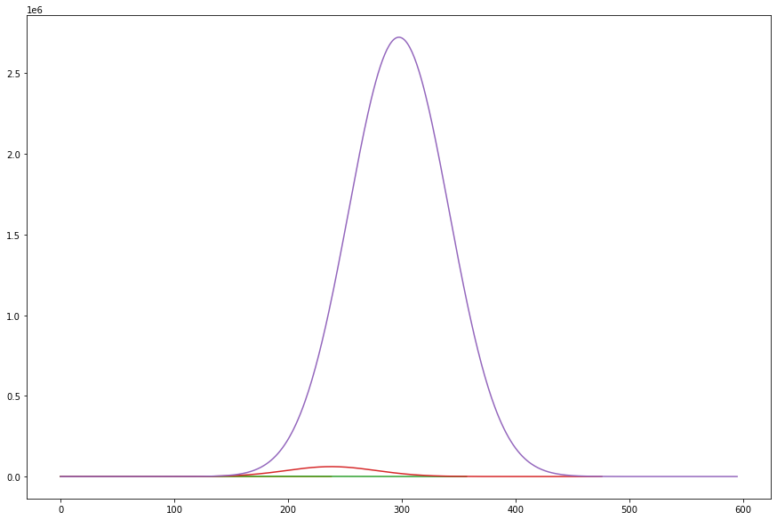

```python
def gaussian(x, mu, sig):
    return np.exp(-np.power(x - mu, 2.) / (2 * np.power(sig, 2.)))

x_values = np.linspace(-3, 3, 120)

# initial gaussian distribution
p = gaussian(x_values, 0, 1)
plt.plot(p)
print("Standard deviation of intial Gaussian distribution:", np.std(p))

# convolutions
p2 = np.convolve(p, p)
p3 = np.convolve(p2, p)
p4 = np.convolve(p3, p)
p5 = np.convolve(p4, p)

print("Standard deviation of summed/averaged over Gaussian distribution:", np.std(p5))

# plotting the convolutions
plt.plot(p2)
plt.plot(p3)
plt.plot(p4)
plt.plot(p5)

plt.show()
```

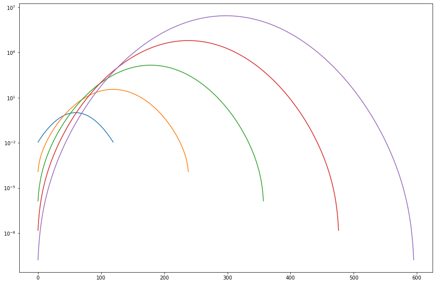

```python
# distribution on log scales
plt.plot(p)
plt.plot(p2)
plt.plot(p3)
plt.plot(p4)
plt.plot(p5)
plt.yscale('log')
plt.show()
```